### In this project a dataset about costs for health insurance was used to practice a few machine learning models in R.

```r
library(fastDummies)
library(ggplot2)
library(plotly)
library(hrbrthemes)
library(extrafont)
library(corrgram)
library(caret)
library(caTools)
library(rpart)
library(forecast)
library(ISLR)
library(rattle)
library(rpart.plot)
library(RColorBrewer)
library(dplyr)
library(ConfusionTableR)
library(tidyr)
library(mlbench)
```

```r
#Reading the data

df = read.csv("E:/Usuarios/Documentos/R/Medical Insurance/insurance.csv", na.strings="", stringsAsFactors = T)
head(df)
```

```
##   age    sex    bmi children smoker    region   charges
## 1  19 female 27.900        0    yes southwest 16884.924
## 2  18   male 33.770        1     no southeast  1725.552
## 3  28   male 33.000        3     no southeast  4449.462
## 4  33   male 22.705        0     no northwest 21984.471
## 5  32   male 28.880        0     no northwest  3866.855
## 6  31 female 25.740        0     no southeast  3756.622
```

```r
summary(df)
```

```
##       age            sex           bmi           children     smoker
##  Min.   :18.00   female:662   Min.   :15.96   Min.   :0.000   no :1064
##  1st Qu.:27.00   male  :676   1st Qu.:26.30   1st Qu.:0.000   yes: 274
##  Median :39.00                Median :30.40   Median :1.000
##  Mean   :39.21                Mean   :30.66   Mean   :1.095
##  3rd Qu.:51.00                3rd Qu.:34.69   3rd Qu.:2.000
##  Max.   :64.00                Max.   :53.13   Max.   :5.000
##        region       charges
##  northeast:324   Min.   : 1122
##  northwest:325   1st Qu.: 4740
##  southeast:364   Median : 9382
##  southwest:325   Mean   :13270
##                  3rd Qu.:16640
##                  Max.   :63770
```

```r
#checking missing data
df[!complete.cases(df),]
```

```
## [1] age      sex      bmi      children smoker   region   charges
## <0 linhas> (ou row.names de comprimento 0)
```

```r
#Checking duplicated rows
#df[!duplicated(df),]
sum(duplicated(df))
```

```
## [1] 1
```

Exploring the variables

1.Age

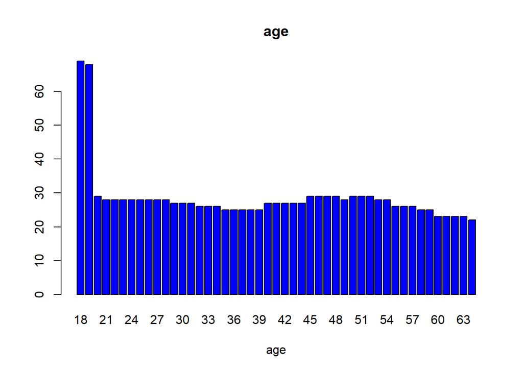

```r
Counts = table(df$age)
barplot(Counts, main="age", xlab="age",  col = c("blue"))
```

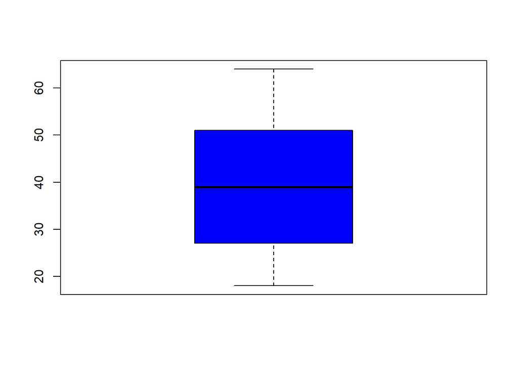

```r
boxplot(df$age, col = c("blue"))
```

```r
summary(df$age)
```

```
##    Min. 1st Qu.  Median    Mean 3rd Qu.    Max.
##   18.00   27.00   39.00   39.21   51.00   64.00
```

2.Sex

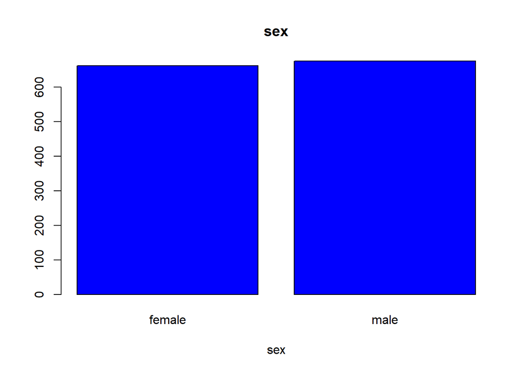

```r
Counts = table(df$sex)
barplot(Counts, main="sex", xlab="sex", col = c("blue"))
```

3.BMI

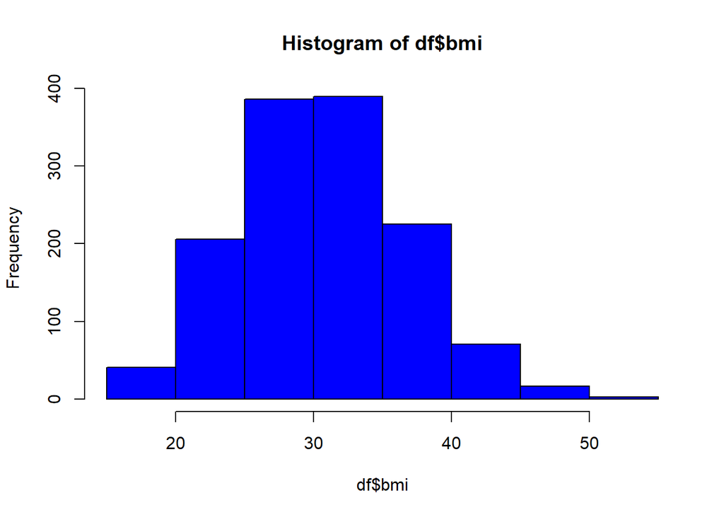

```r
hist(df$bmi, col = c("blue"))
```

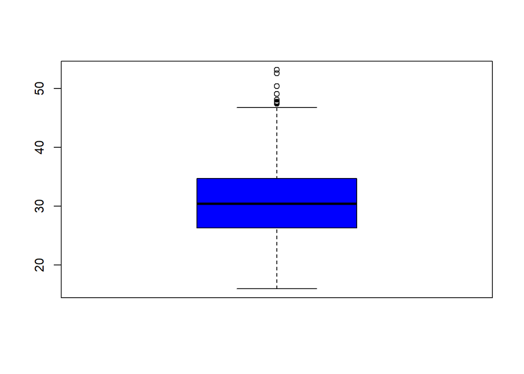

```r
boxplot(df$bmi,  col = c("blue"))
```

```r
summary(df$bmi)
```

```
##    Min. 1st Qu.  Median    Mean 3rd Qu.    Max.
##   15.96   26.30   30.40   30.66   34.69   53.13
```

4.Children

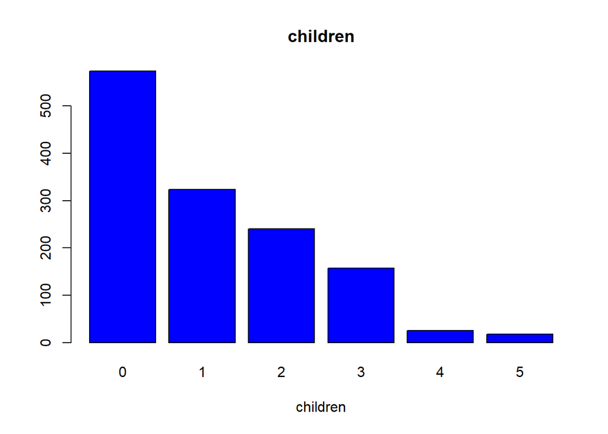

```r
Counts = table(df$children)
barplot(Counts, main="children", xlab="children",col = c("blue"))
```

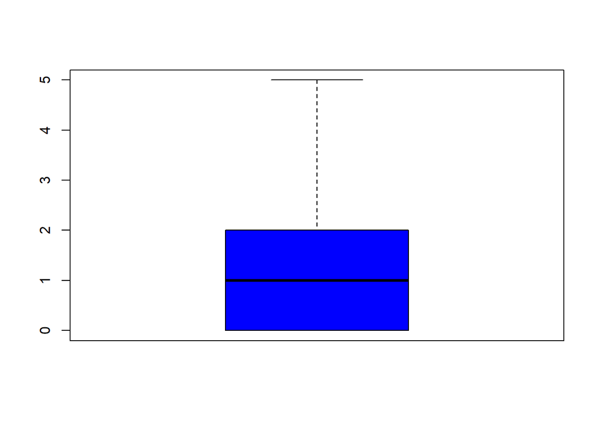

```r
boxplot(df$children,  col = c("blue"))
```

```r
summary(df$children)
```

```
##    Min. 1st Qu.  Median    Mean 3rd Qu.    Max.
##   0.000   0.000   1.000   1.095   2.000   5.000
```

5.Smoker

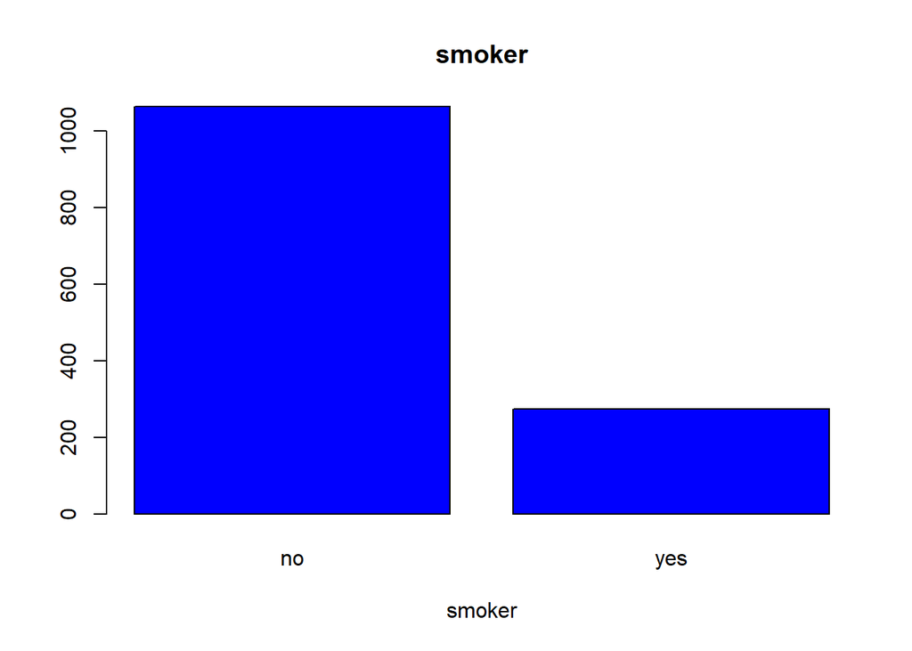

```r
Counts = table(df$smoker)
barplot(Counts, main="smoker", xlab="smoker",col = c("blue"))
```

6.Region

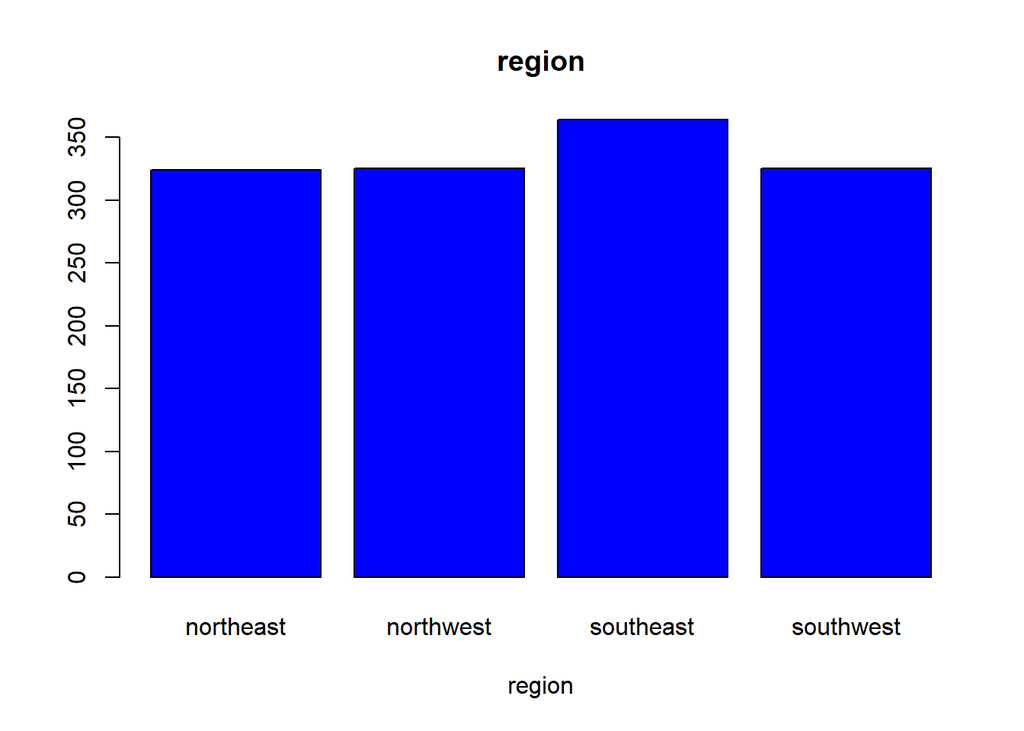

```r
Counts = table(df$region)
barplot(Counts, main="region", xlab="region",col = c("blue"))
```

Variable Response - Charges

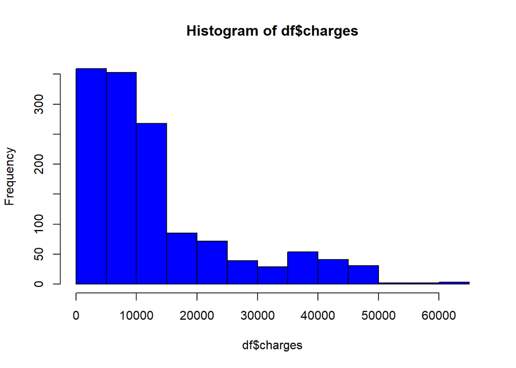

```r
hist(df$charges,col = c("blue"))
```

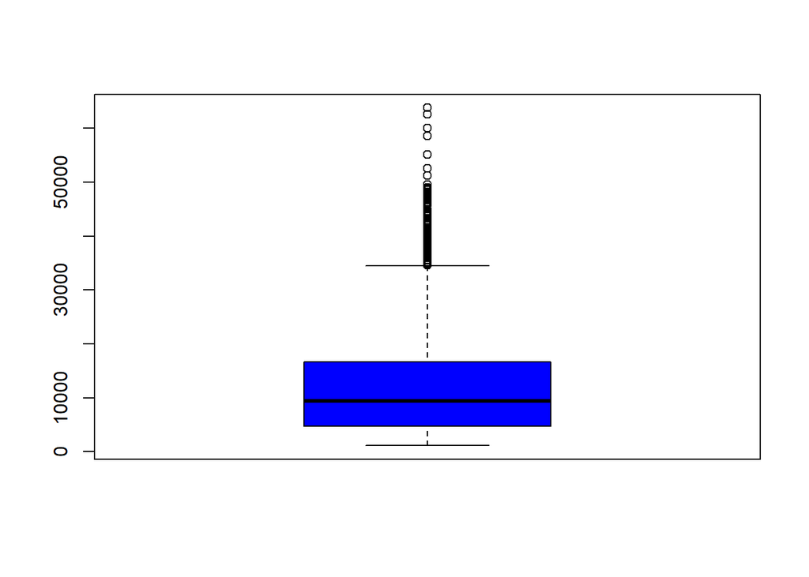

```r
boxplot(df$charges,  col = c("blue"))
```

```r
summary(df$charges)
```

```
##    Min. 1st Qu.  Median    Mean 3rd Qu.    Max.
##    1122    4740    9382   13270   16640   63770
```

We can see that charges don’t have a normal distribution, making a log transformation give us a distribution that tends to normal. For this project that transformation will suffice.

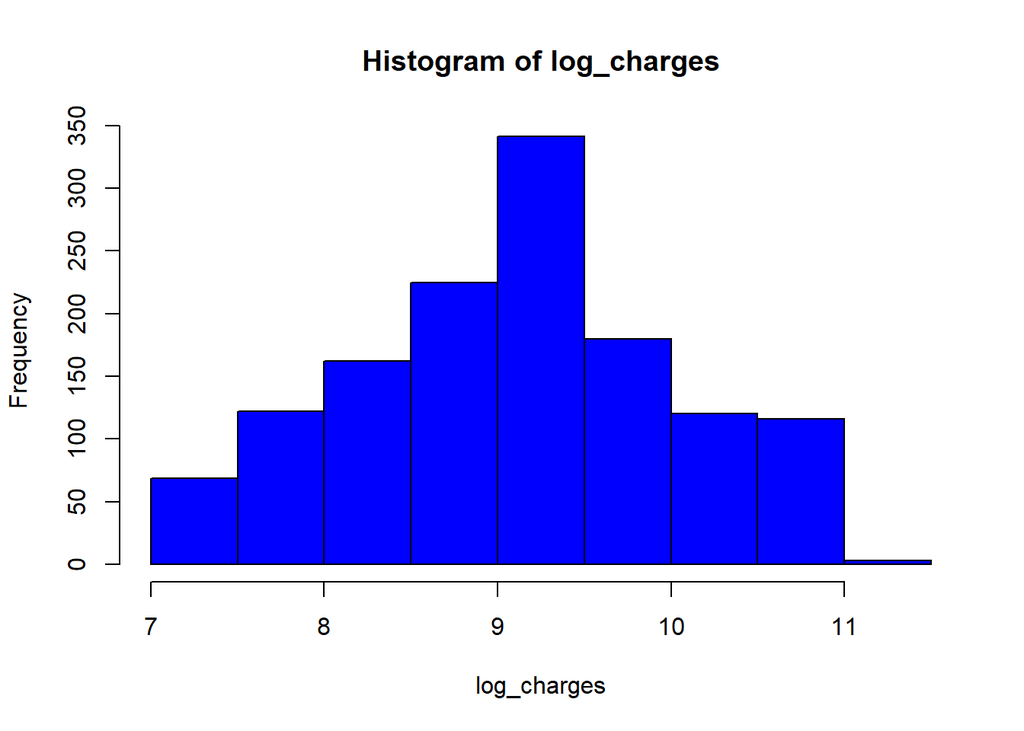

```r
log_charges = log(df$charges)
hist(log_charges,col = c("blue"))
```

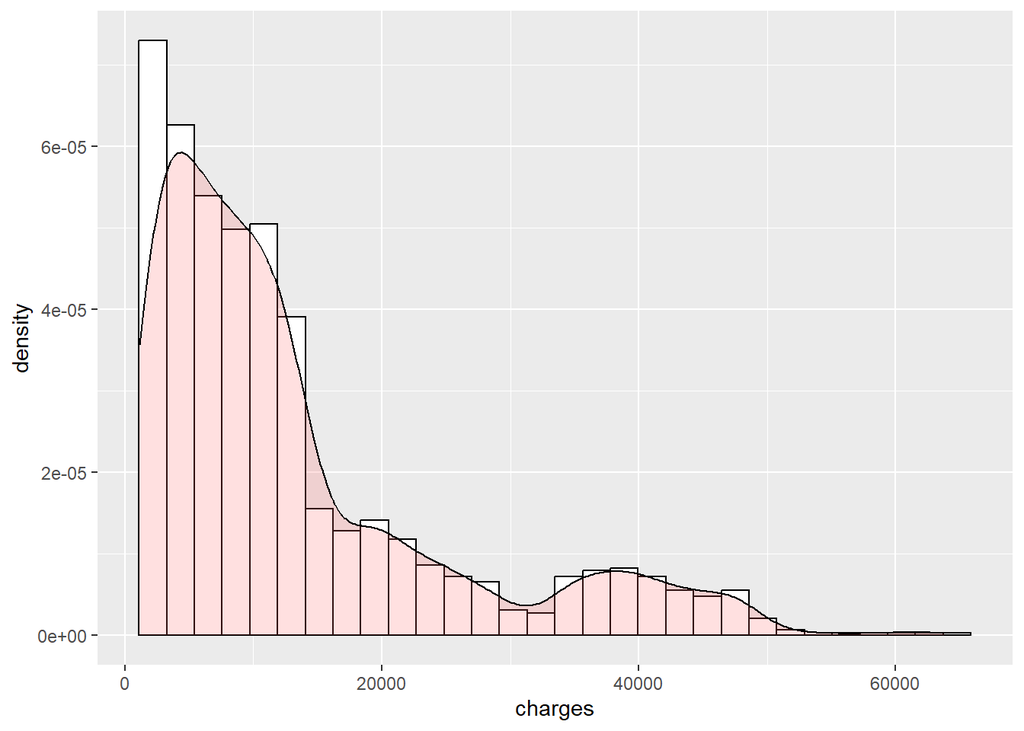

```r
# Histogram overlaid with kernel density curve
ggplot(df, aes(x=charges)) +
    geom_histogram(aes(y=after_stat(density)),
                   colour="black", fill="white") +
    geom_density(alpha=.2, fill="#FF6666")
```

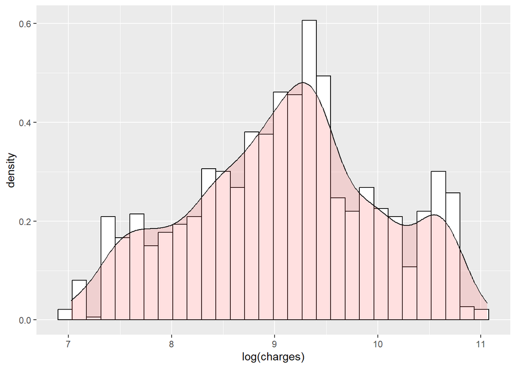

```r
ggplot(df, aes(x=log(charges))) +
    geom_histogram(aes(y=after_stat(density)),
                   colour="black", fill="white") +
    geom_density(alpha=.2, fill="#FF6666")
```

Let’s explore how other variables behave in relation to our response variable.

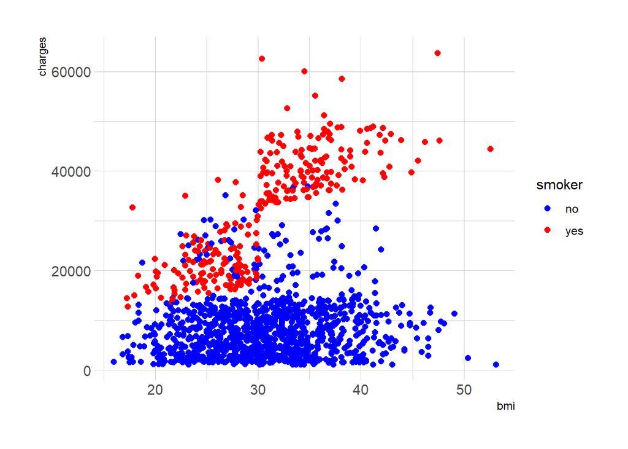

```r
ggplot(df, aes(x=bmi, y=charges, color=smoker)) +
    geom_point(size=2) +
    theme_ipsum() +
    scale_color_manual(values=c("blue", "red"))
```

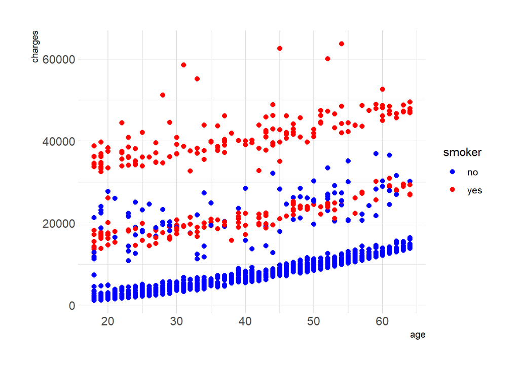

```r
ggplot(df, aes(x=age, y=charges, color=smoker)) +
    geom_point(size=2) +
    theme_ipsum() +
    scale_color_manual(values=c("blue", "red"))
```

From those plots we can see that people who smoke have higher costs. It seems that’s the biggest correlation with the costs even without checking the correlation. Cost also seems to increase slightly with Age and BMI. We will check further correlations in the pre-processing step.

### Pre-processing data

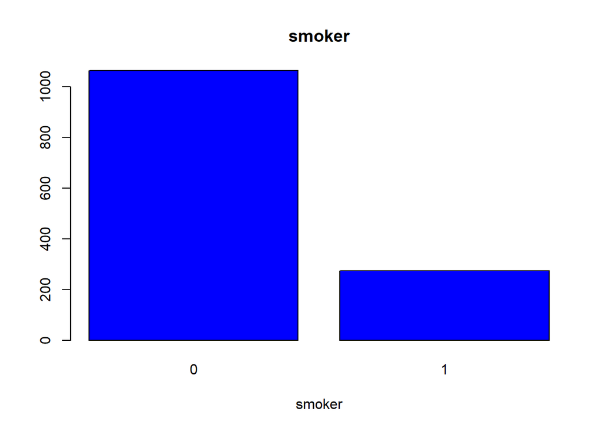

```r
#Changing yes and no to 0 and 1 in the column smoker
df$smoker<-ifelse(df$smoker=="yes",1,0)
Counts = table(df$smoker)
barplot(Counts, main="smoker", xlab="smoker",  col = c("blue"))
```

```r
#One hot encoding on the categorical variables remaining
df <- dummy_cols(df,select_columns = "sex")
df <- dummy_cols(df,select_columns = "region")
```

```r
df = subset(df, select = -c(region) )
df = subset(df, select = -c(sex) )
```

```r
#Checking the correlation of our variables
cor(cor(df))
```

```
##                           age         bmi    children      smoker     charges
## age               1.000000000  0.10640381 -0.04474510 -0.04287092  0.27287447
## bmi               0.106403812  1.00000000 -0.10163657 -0.01718504  0.16151499
## children         -0.044745096 -0.10163657  1.00000000 -0.10467372 -0.08116170
## smoker           -0.042870924 -0.01718504 -0.10467372  1.00000000  0.92139533
## charges           0.272874468  0.16151499 -0.08116170  0.92139533  1.00000000
## sex_female        0.047469334 -0.09425464 -0.02755352 -0.15030057 -0.12558313
## sex_male         -0.047469334  0.09425464  0.02755352  0.15030057  0.12558313
## region_northeast  0.008364004 -0.26365942 -0.03651218  0.02318241  0.01254347
## region_northwest -0.002118621 -0.26357731  0.06462370 -0.06801243 -0.08568219
## region_southeast -0.020283841  0.50836250 -0.07097172  0.12123180  0.15317537
## region_southwest  0.015590976 -0.01794667  0.04812693 -0.08549361 -0.09145913
##                    sex_female     sex_male region_northeast region_northwest
## age               0.047469334 -0.047469334      0.008364004     -0.002118621
## bmi              -0.094254643  0.094254643     -0.263659424     -0.263577306
## children         -0.027553519  0.027553519     -0.036512183      0.064623697
## smoker           -0.150300570  0.150300570      0.023182412     -0.068012431
## charges          -0.125583128  0.125583128      0.012543467     -0.085682192
## sex_female        1.000000000 -1.000000000      0.007545555      0.027643224
## sex_male         -1.000000000  1.000000000     -0.007545555     -0.027643224
## region_northeast  0.007545555 -0.007545555      1.000000000     -0.299347330
## region_northwest  0.027643224 -0.027643224     -0.299347330      1.000000000
## region_southeast -0.043550315  0.043550315     -0.361527173     -0.366305472
## region_southwest  0.011545616 -0.011545616     -0.313282321     -0.310669169
##                  region_southeast region_southwest
## age                   -0.02028384       0.01559098
## bmi                    0.50836250      -0.01794667
## children              -0.07097172       0.04812693
## smoker                 0.12123180      -0.08549361
## charges                0.15317537      -0.09145913
## sex_female            -0.04355031       0.01154562
## sex_male               0.04355031      -0.01154562
## region_northeast      -0.36152717      -0.31328232
## region_northwest      -0.36630547      -0.31066917
## region_southeast       1.00000000      -0.34612202
## region_southwest      -0.34612202       1.00000000
```

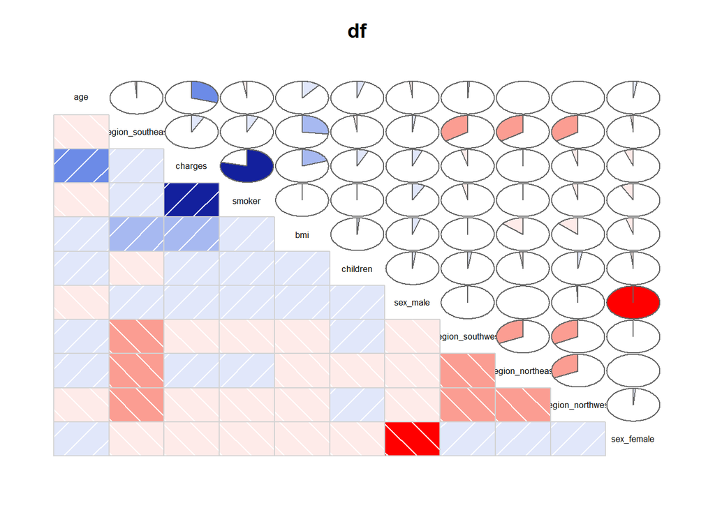

```r
corrgram(df, order = TRUE, lower.panel = panel.shade, upper.panel = panel.pie, text.panel = panel.txt, main="df")
```

Smoker variable has the highest correlation with our response variable as we suspected. Age and BMI don’t have a strong correlation, but are the next ones with the highest correlation with charges variable.

Next we will apply log in the response variable and make some simple re-scaling in age and BMI.

```r
df$charges <- log(df$charges)
```

```r
df$bmi <- (df$bmi)/100
df$age <- (df$age)/100
```

```r
#Splitting data into train-test samples
split = sample.split(Y=df$charges, SplitRatio=0.8)
train = df[split,]
test = df[!split,]

dim(train)
```

```
## [1] 1070   11
```

```r
dim(test)
```

```
## [1] 268  11
```

### Multiple Linear Regression

Our first ML analysis is a multiple linear regression to determine the medical costs. ‘Smoker’, ‘Age’ and ‘BMI’ are our independent variables in this scenario.

```r
lr_model = lm(charges ~ smoker + age + bmi, data = train)
lr_model
```

```
##
## Call:
## lm(formula = charges ~ smoker + age + bmi, data = train)
##
## Coefficients:
## (Intercept)       smoker          age          bmi
##       7.082        1.547        3.507        1.066
```

```r
summary(lr_model)
```

```
##
## Call:
## lm(formula = charges ~ smoker + age + bmi, data = train)
##
## Residuals:
##      Min       1Q   Median       3Q      Max
## -1.22057 -0.22135 -0.04101  0.09961  2.07017
##
## Coefficients:
##             Estimate Std. Error t value Pr(>|t|)
## (Intercept)  7.08203    0.08064  87.827  < 2e-16 ***
## smoker       1.54714    0.03645  42.448  < 2e-16 ***
## age          3.50714    0.10222  34.310  < 2e-16 ***
## bmi          1.06610    0.23471   4.542  6.2e-06 ***
## ---
## Signif. codes:  0 '***' 0.001 '**' 0.01 '*' 0.05 '.' 0.1 ' ' 1
##
## Residual standard error: 0.4689 on 1066 degrees of freedom
## Multiple R-squared:  0.7346, Adjusted R-squared:  0.7338
## F-statistic: 983.3 on 3 and 1066 DF,  p-value: < 2.2e-16
```

```r
Prediction <-predict(lr_model, newdata=test)
results <- data.frame(Actual= test$charges, Prediction)
head(results)
```

```
##       Actual Prediction
## 9   8.765054   8.697684
## 22  8.330800   8.479583
## 26  9.546894   9.446760
## 35 10.843389   9.999223
## 36  7.393530   7.966133
## 40 10.782561  11.158820
```

```r
RSQUARE = function(y_actual,y_predict){
  cor(y_actual,y_predict)^2
}
MAPE = function(y_actual,y_predict){
  mean(abs((y_actual-y_predict)/y_actual))*100
}
```

```r
model_R_Squared = RSQUARE(test$charges, Prediction)
model_R_Squared
```

```
## [1] 0.7788096
```

```r
model_MAPE = MAPE(test$charges, Prediction)
model_MAPE
```

```
## [1] 3.322978
```

```r
Accuracy_Linear = 100 - model_MAPE
Accuracy_Linear
```

```
## [1] 96.67702
```

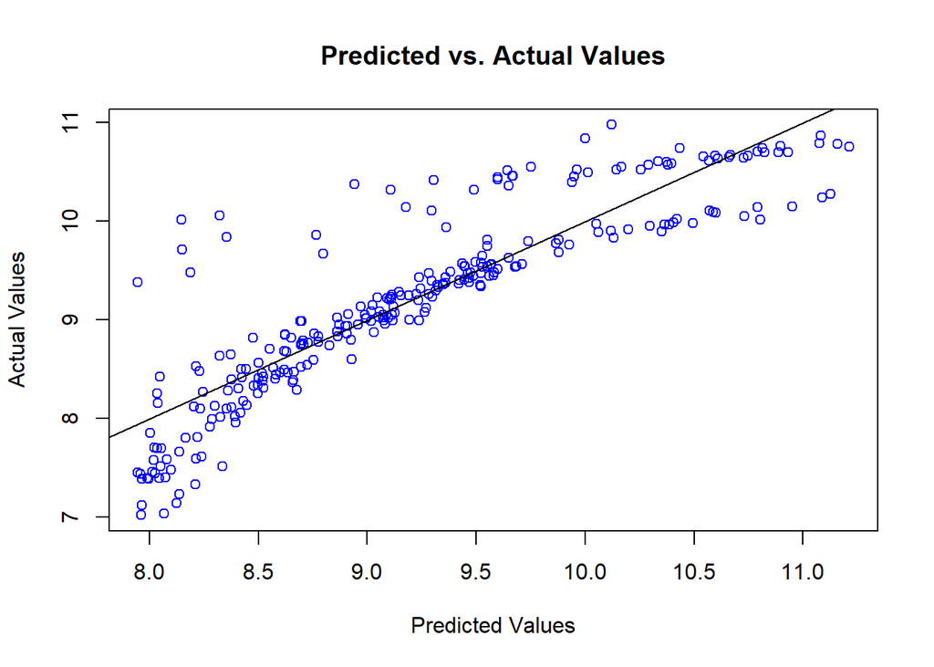

```r
plot(Prediction, y= test$charges,
     xlab='Predicted Values',
     ylab='Actual Values',
     main='Predicted vs. Actual Values',col = c("blue"))
abline(a=0, b=1)
```